# Metabolite screen maize root bacteria

Thoenen et al. AMPO formation

Lisa Thönen

2024-05-14

Here we analyse the metabolite data from the maize root bacteria screening experiment in December 2019.

Some strains had to be excluded because they grew bad in the assay. This was checked by optical density measurement of the 96 well plates (which was prone to give false results because there condensed water forms below the lid which affects the measurements) and by measuring two amino acids in the cultures. LMR1 was excluded because of unsure taxonomy (Paenib. or neorhizobium). The antibiotic resistant strains LPB4.R, “LRC7.S and LRH8.S were also excluded and only their orignals (xyz.O) kept.

| Strain | Genus | Phylum |
| --- | --- | --- |
| LRH8.O | Rhizobium | Proteobacteria |
| LST17 | Stenotrophomonas | Proteobacteria |
| LMX3 | Micrococcineae | Actinobacteria |
| LMX8 | Bacillus | Firmicutes |
| LRC7.S | Rhizobium | Proteobacteria |
| LMR1 | Neorhizobium | Proteobacteria |
| LPB4.R | Pseudomonas | Proteobacteria |
| LMC1 | Pantoea | Proteobacteria |
| LMX11 | Pseudomonas | Proteobacteria |
| LRH8.S | Rhizobium | Proteobacteria |
| LMK1 | Pantoea | Proteobacteria |
| LME2 | Bacillus | Firmicutes |

**Dilutions**

All the samples (except T0 samples) were diluted with acidified MeOH in a ratio (30:70 - sample:MeOH). Then they were diluted 1:6 in the pooled eppi and 1:10 in the analysis vial, resulting in a final dilution of 200. The T0 samples were diluted 1:6. Therefore the values have to be adjusted to the dilution.

# BX profiles of media controls

Benzoxazinoids were mixed to TSB growth media, each at a concentration of 500 uM. BXs were MBOA, DIMBOA and DIMBOA-Glc. The treatments were diluted and frozen directly at the start of the experiment (T0) and incubated without bacteria throughout the experiment (NBC). The T0 samples were differently diluted at the beginning, therefore they were here normalized with MBOA values (*35) - MBOA is stable in these conditions. NBC and T0 plotted show the spontaneous degradation of the BXs in the culture growth conditions.

MBOA seems to be pure and stable over the course of the experiment. DIMBOA is not stable and degrades completly to MBOA. As the profile shows at T0 it is not pure and also contains HMBOA which degrades to BOA.

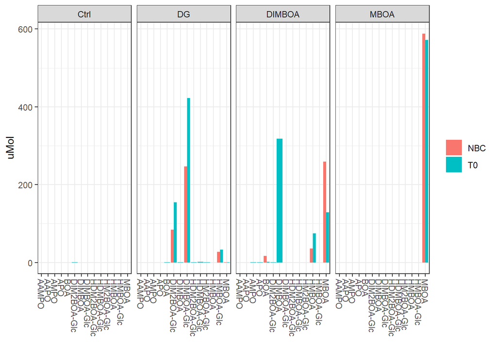

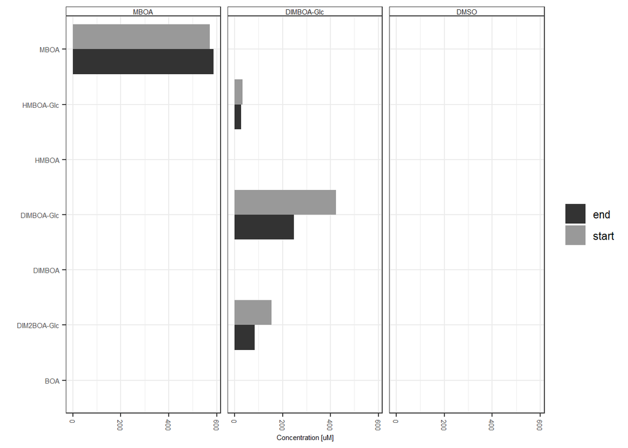

# MBOA assay

## Qualitative analysis

Since there is quite some variation in the absolute values of metabolites in the cultures, which makes it difficult to categorize the bacteria to metabolic types, we to qualitative categorization of the bacteria to groups. We define threshold concentrations of the supplemented compounds (MBOA & DIMBOA-Glc) to group bacteria into “degraders” or “non-degraders” and for metabolization products (AMPO & AAMPO) to group in “formers” and “non-formers”.

### classification

**MBOA degradation**

We define thresholds for *strong*, *weak* and *non-degraders* of MBOA relative to the MBOA levels detected in the NBC sample (587.5834 μM):

*strong MBOA degraders*: ≤10% of MBOA levels compared to NBC detected (10% = 58.75834).

*weak MBOA degraders*: 70% > x > 10% of MBOA levels compared to NBC detected.

*non-degraders of MBOA*: ≥70% of MBOA levels compared to NBC detected (70% = 411.3084).

**AMPO formation**

We define thresholds for *non-*, *weak* or *strong* AMPO formers relative to maximum level of AMPO formed by one of the strains (42.49294 µM):

*non-formers of AMPO:* form <0.1% of AMPO compared to the max. AMPO-former (0.1% = 0.04249294 µM).

*weak AMPO-formers:* form 10% > x 0.1% of AMPO compared to the max. AMPO-former.

*Strong AMPO-formers:* form >10% of AMPO compared to the max. AMPO-former (10% = 4.249294 µM).

**AAMPO formation**

We did not define thresholds for AAMPO formers, but recorded if AAMPO was detected in a culture.

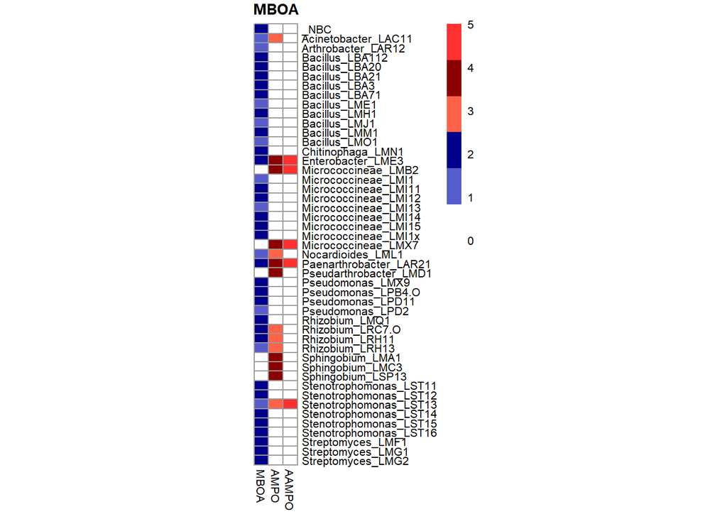

## Quantitative analysis

### bargraph all compounds

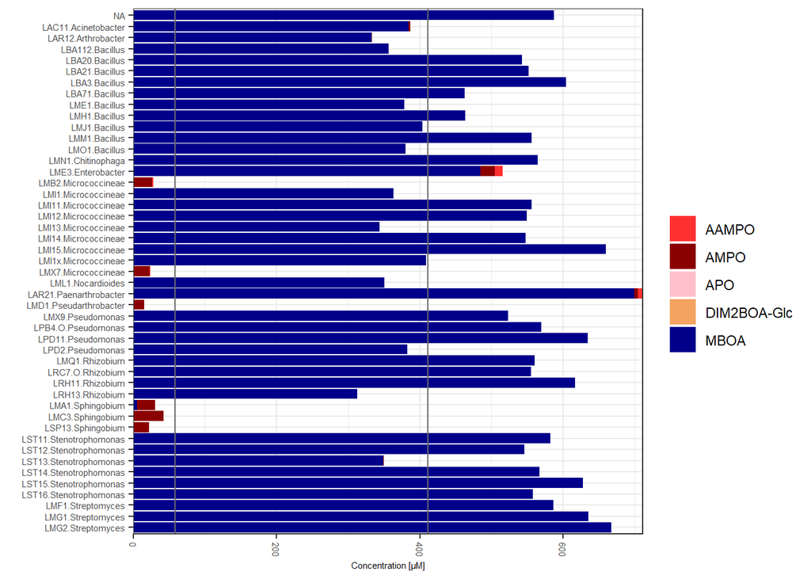

### bargraph (A)AMPO

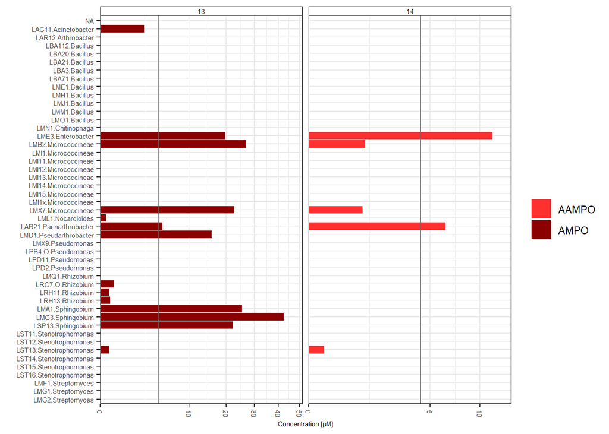

# DIMBOA-Glc assay

## Qualitative analysis

### classification

**DIMBOA-Glc degradation**

We define thresholds for *strong*, *weak* and *non-degraders* of DIMBOA-Glc relative to the DIMBOA-Glc levels detected in the NBC sample (246.9373 μM). Of note, this DIMBOA-Glc amounts were lower compared to MBOA because the DIMBOA-Glc we used, was of 70% purity.

*strong DIMBOA-Glc degraders*: ≤10% of DIMBOA-Glc levels compared to NBC detected (10% = 24.69373 µM).

*weak DIMBOA-Glc degraders*: 70% > x > 10% of DIMBOA-Glc levels compared to NBC detected.

*non-degraders of DIMBOA-Glc*: ≥70% of DIMBOA-Glc levels compared to NBC detected (70% = 172.8561 µM).

**MBOA formation after DIMBOA-Glc degradation**

We define thresholds for *non-*, *weak* or *strong* MBOA formers relative to maximum level of MBOA formed by one of the strains in DIMBOA-Glc medium (143.2905 µM):

*non-formers of MBOA:* form <0.1% of MBOA compared to the max. MBOA-former (0.1% = 0.1432905 µM).

*weak MBOA-formers:* form 10% > x 0.1% of MBOA compared to the max. MBOA-former.

*Strong MBOA-formers:* form >10% of MBOA compared to the max. MBOA-former (10% = 14.32905 µM).

**AMPO formation after DIMBOA-Glc degradation**

We took the same thresholds for *non-*, *weak* or *strong* AMPO formers for the DIMBOA-Glc assay as in the MBOA assay.

**AAMPO formation after DIMBOA-Glc degradation**

We did not define thresholds for AAMPO formers, but recorded if AAMPO was detected in a culture.

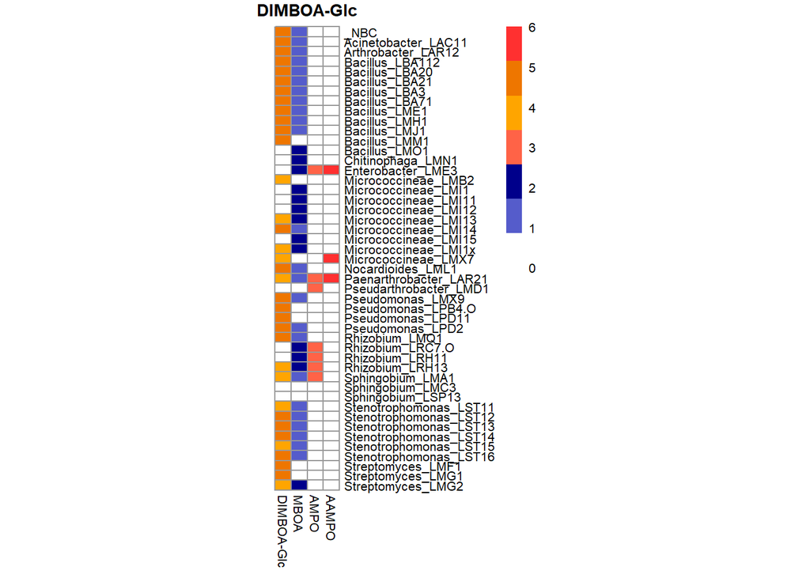

## Quantitative analysis

### bargraph all compounds

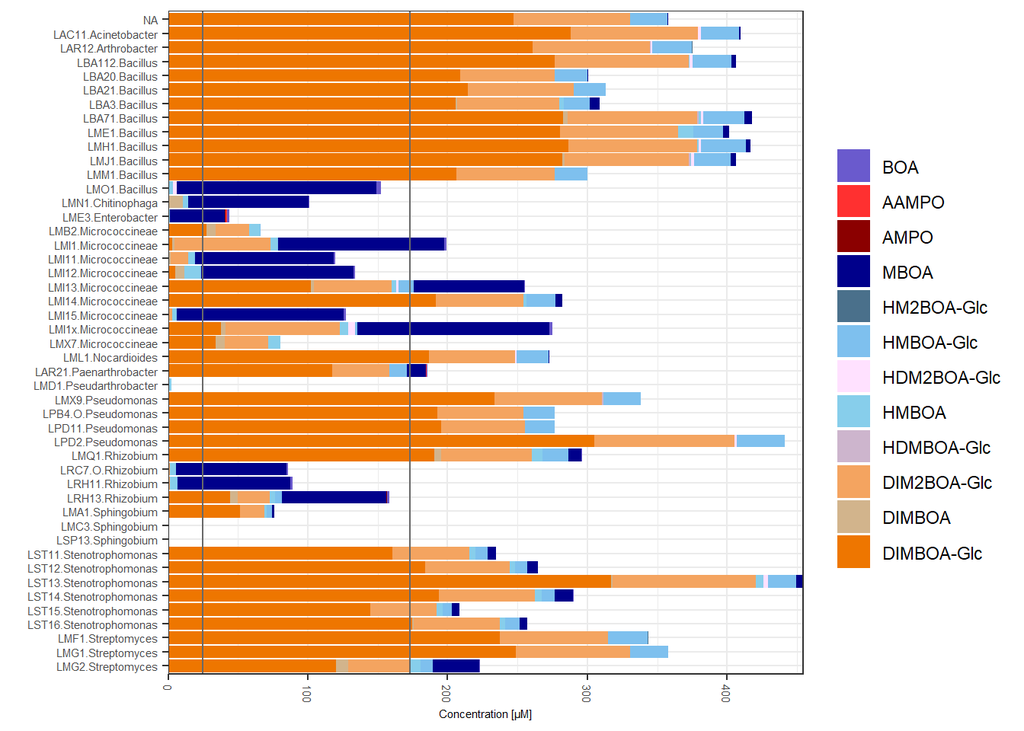

### bargraph (A)AMPO

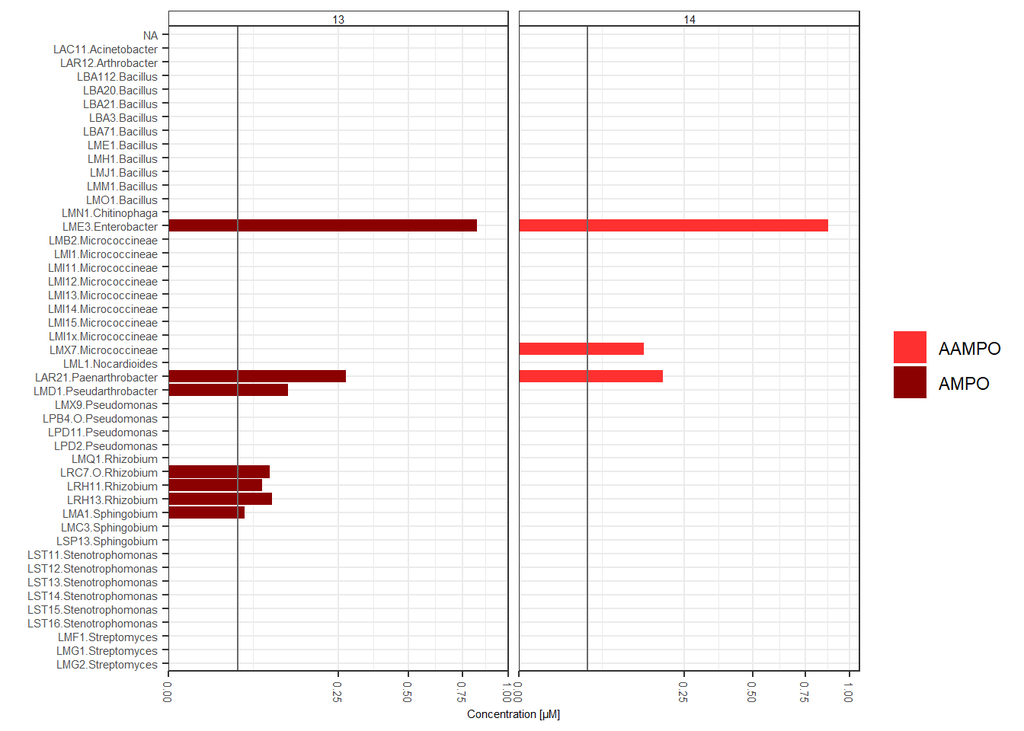